# Customer segmentation data analysis

```python
import numpy as np
import pandas as pd
import matplotlib.pyplot as plt
import seaborn as sns
```

```python
df = pd.read_csv("customer_segmentation_data.csv")
```

```python
df
```

|  | Customer ID | Age | Gender | Marital Status | Education Level | Geographic Information | Occupation | Income Level | Behavioral Data | Purchase History | Interactions with Customer Service | Insurance Products Owned | Coverage Amount | Premium Amount | Policy Type | Customer Preferences | Preferred Communication Channel | Preferred Contact Time | Preferred Language | Segmentation Group |
| --- | --- | --- | --- | --- | --- | --- | --- | --- | --- | --- | --- | --- | --- | --- | --- | --- | --- | --- | --- | --- |
| 0 | 84966 | 23 | Female | Married | Associate Degree | Mizoram | Entrepreneur | 70541 | policy5 | 04-10-2018 | Phone | policy2 | 366603 | 2749 | Group | Email | In-Person Meeting | Afternoon | English | Segment5 |
| 1 | 95568 | 26 | Male | Widowed | Doctorate | Goa | Manager | 54168 | policy5 | 11-06-2018 | Chat | policy1 | 780236 | 1966 | Group | Mail | In-Person Meeting | Morning | French | Segment5 |
| 2 | 10544 | 29 | Female | Single | Associate Degree | Rajasthan | Entrepreneur | 73899 | policy5 | 06-05-2021 | Email | policy3 | 773926 | 4413 | Group | Email | Mail | Evening | German | Segment3 |
| 3 | 77033 | 20 | Male | Divorced | Bachelor's Degree | Sikkim | Entrepreneur | 63381 | policy5 | 09-02-2018 | Chat | policy2 | 787815 | 4342 | Family | Text | In-Person Meeting | Anytime | French | Segment3 |
| 4 | 88160 | 25 | Female | Separated | Bachelor's Degree | West Bengal | Manager | 38794 | policy1 | 09-10-2018 | Chat | policy4 | 366506 | 1276 | Family | Email | Text | Weekends | English | Segment2 |
| ... | ... | ... | ... | ... | ... | ... | ... | ... | ... | ... | ... | ... | ... | ... | ... | ... | ... | ... | ... | ... |
| 53498 | 44809 | 35 | Female | Divorced | Associate Degree | Andaman and Nicobar Islands | Salesperson | 120850 | policy3 | 01-01-2019 | Mobile App | policy1 | 586401 | 4404 | Family | In-Person Meeting | Phone | Afternoon | German | Segment5 |
| 53499 | 65485 | 61 | Male | Single | Doctorate | Himachal Pradesh | Entrepreneur | 122309 | policy5 | 5/18/2021 | Mobile App | policy4 | 637733 | 1285 | Group | Text | Mail | Afternoon | German | Segment1 |
| 53500 | 26213 | 25 | Male | Divorced | Doctorate | Assam | Teacher | 49258 | policy2 | 11/27/2018 | In-Person | policy1 | 631057 | 4407 | Individual | Text | Text | Weekends | French | Segment4 |
| 53501 | 63136 | 42 | Male | Married | Doctorate | Andhra Pradesh | Artist | 66301 | policy4 | 06-04-2021 | In-Person | policy1 | 730385 | 4482 | Business | Mail | Phone | Morning | French | Segment5 |
| 53502 | 62125 | 20 | Male | Divorced | Doctorate | Daman and Diu | Salesperson | 136632 | policy2 | 10/14/2022 | Phone | policy1 | 743262 | 4499 | Group | Text | In-Person Meeting | Evening | German | Segment2 |

53503 rows × 20 columns

```python
df.shape
```

```
(53503, 20)
```

```python
df.info()
```

```
<class 'pandas.core.frame.DataFrame'>
RangeIndex: 53503 entries, 0 to 53502
Data columns (total 20 columns):
 #   Column                              Non-Null Count  Dtype
---  ------                              --------------  -----
 0   Customer ID                         53503 non-null  int64
 1   Age                                 53503 non-null  int64
 2   Gender                              53503 non-null  object
 3   Marital Status                      53503 non-null  object
 4   Education Level                     53503 non-null  object
 5   Geographic Information              53503 non-null  object
 6   Occupation                          53503 non-null  object
 7   Income Level                        53503 non-null  int64
 8   Behavioral Data                     53503 non-null  object
 9   Purchase History                    53503 non-null  object
 10  Interactions with Customer Service  53503 non-null  object
 11  Insurance Products Owned            53503 non-null  object
 12  Coverage Amount                     53503 non-null  int64
 13  Premium Amount                      53503 non-null  int64
 14  Policy Type                         53503 non-null  object
 15  Customer Preferences                53503 non-null  object
 16  Preferred Communication Channel     53503 non-null  object
 17  Preferred Contact Time              53503 non-null  object
 18  Preferred Language                  53503 non-null  object
 19  Segmentation Group                  53503 non-null  object
dtypes: int64(5), object(15)
memory usage: 8.2+ MB
```

```python
df.describe()
```

|  | Customer ID | Age | Income Level | Coverage Amount | Premium Amount |
| --- | --- | --- | --- | --- | --- |
| count | 53503.000000 | 53503.000000 | 53503.000000 | 53503.000000 | 53503.000000 |
| mean | 52265.204998 | 44.140945 | 82768.324318 | 492580.789638 | 3023.702447 |
| std | 28165.000067 | 15.079486 | 36651.075670 | 268405.505571 | 1285.834295 |
| min | 1.000000 | 18.000000 | 20001.000000 | 50001.000000 | 500.000000 |
| 25% | 28950.500000 | 32.000000 | 51568.500000 | 249613.500000 | 1817.000000 |
| 50% | 55858.000000 | 43.000000 | 80719.000000 | 477261.000000 | 3194.000000 |
| 75% | 76096.000000 | 57.000000 | 115973.500000 | 739124.000000 | 4311.500000 |
| max | 100000.000000 | 70.000000 | 149999.000000 | 1000000.000000 | 5000.000000 |

```python
df.isna().sum()
```

```
Customer ID                           0
Age                                   0
Gender                                0
Marital Status                        0
Education Level                       0
Geographic Information                0
Occupation                            0
Income Level                          0
Behavioral Data                       0
Purchase History                      0
Interactions with Customer Service    0
Insurance Products Owned              0
Coverage Amount                       0
Premium Amount                        0
Policy Type                           0
Customer Preferences                  0
Preferred Communication Channel       0
Preferred Contact Time                0
Preferred Language                    0
Segmentation Group                    0
dtype: int64
```

```python
df.duplicated().sum()
```

```
0
```

# Data Analysis

```python
# Identifying numerical and categorical columns

num_cols = df.select_dtypes(include='number').columns
cat_cols = df.select_dtypes(include='object').columns
```

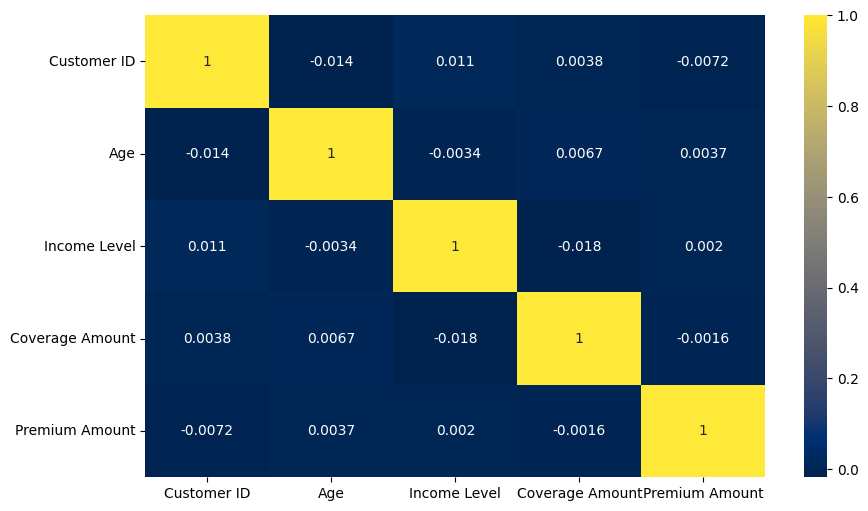

```python
corr = df[num_cols].corr()
plt.figure(figsize=(10, 6))
sns.heatmap(corr, cmap='cividis', annot=True)
```

```python
df[cat_cols].nunique()
```

```
Gender                                   2
Marital Status                           5
Education Level                          5
Geographic Information                  35
Occupation                               9
Behavioral Data                          5
Purchase History                      2016
Interactions with Customer Service       5
Insurance Products Owned                 5
Policy Type                              4
Customer Preferences                     5
Preferred Communication Channel          5
Preferred Contact Time                   5
Preferred Language                       5
Segmentation Group                       5
dtype: int64
```

```
array([[<Axes: title={'center': 'Customer ID'}>,
        <Axes: title={'center': 'Age'}>],
       [<Axes: title={'center': 'Income Level'}>,
        <Axes: title={'center': 'Coverage Amount'}>],
       [<Axes: title={'center': 'Premium Amount'}>, <Axes: >]],
      dtype=object)
```

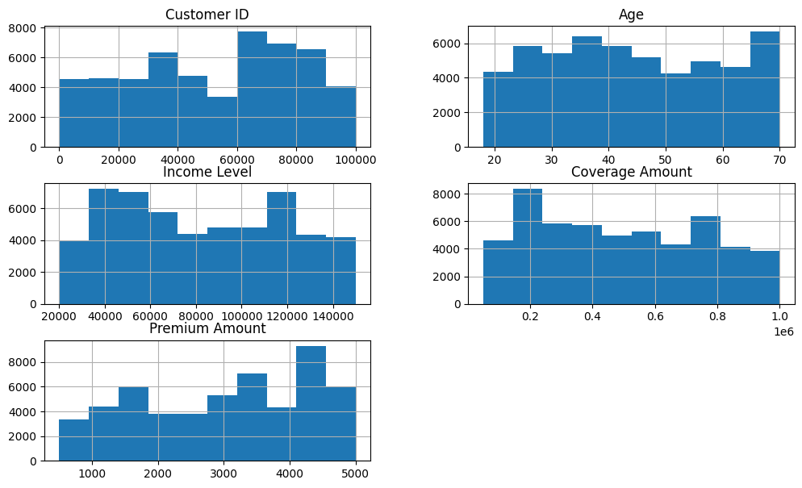

```python
df.hist(figsize=(12, 7))
```

```
Gender Distribution of Customers
Gender: Female, numbers of customers : 26004
Gender: Male, numbers of customers : 27499
```

[output not shown]

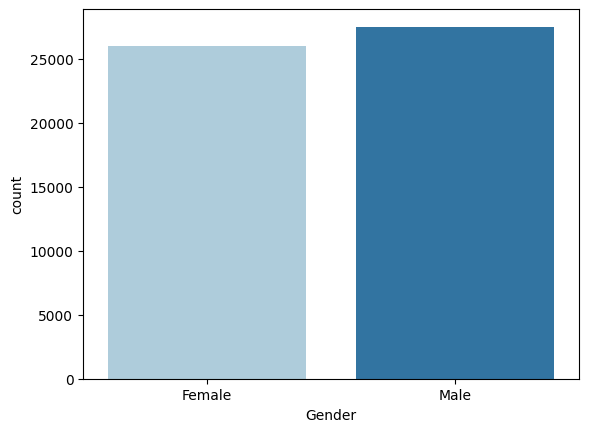

```python
palette = sns.color_palette("Paired")
sns.countplot(data=df, x='Gender', palette = palette)
gender_distribution=df['Gender'].value_counts().sort_index()

print('Gender Distribution of Customers')
for gender , count in gender_distribution.items():
    print(f'Gender: {gender}, numbers of customers : {count}')
```

[output not shown]

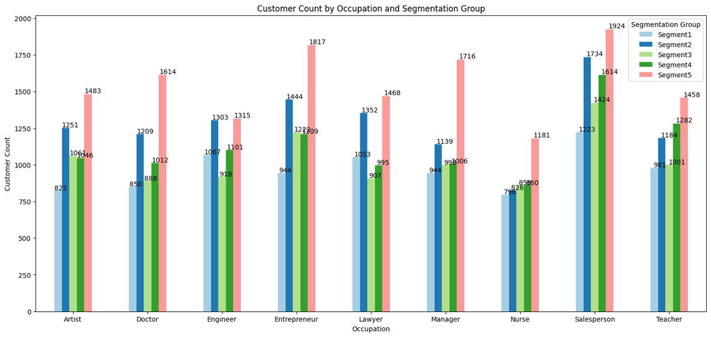

```python
ig, ax = plt.subplots(figsize=(18, 8))
bar_plot = df.groupby(["Occupation", "Segmentation Group"])['Customer ID'].count().unstack().plot(kind='bar', ax=ax,color=palette)

ax.set_title('Customer Count by Occupation and Segmentation Group')
ax.set_xlabel('Occupation')
ax.set_ylabel('Customer Count')

for p in ax.patches:
    ax.annotate(str(p.get_height()), (p.get_x() * 1.005, p.get_height() * 1.005), rotation=0)
plt.xticks(rotation=0)
```

[output not shown]

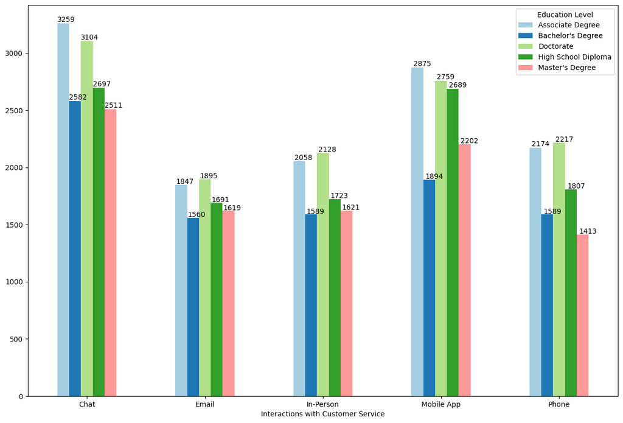

```python
fig, ax = plt.subplots(figsize=(15, 10))
bar_plot = df.groupby(["Interactions with Customer Service", "Education Level"])['Customer ID'].count().unstack().plot(kind='bar', ax=ax,color=palette)


for p in ax.patches:
    ax.annotate(str(p.get_height()), (p.get_x() * 1.005, p.get_height() * 1.005), rotation=0)
plt.xticks(rotation=0)
```

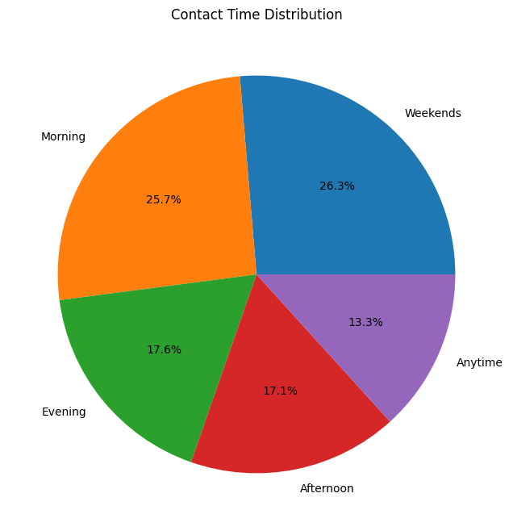

```python
data = df['Preferred Contact Time'].value_counts()

plt.figure(figsize=(12, 8))
plt.pie(data.values, labels=data.index, autopct='%1.1f%%')

plt.title('Contact Time Distribution')
```

[figure not shown]

```python
plt.figure(figsize=(12, 8))
plt.pie(data.values, labels=data.index, autopct='%1.1f%%')

plt.title('Preferred Languages')
```

```
Education level distribution of customers:
Education level : Associate Degree, number of customer: 12213
Education level : Bachelor's Degree, number of customer: 9214
Education level : Doctorate, number of customer: 12103
Education level : High School Diploma, number of customer: 10607
Education level : Master's Degree, number of customer: 9366
```

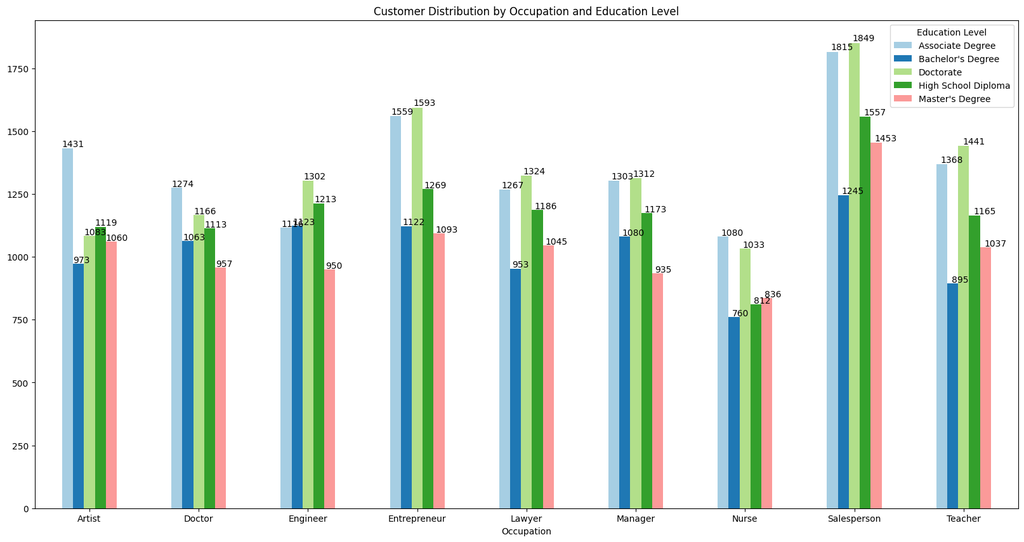

```python
fig, ax = plt.subplots(figsize=(20, 10))
bar_plot = df.groupby(["Occupation", "Education Level"])['Customer ID'].count().unstack().plot(kind='bar', ax=ax, color=palette)

for p in ax.patches:
    ax.annotate(str(p.get_height()), (p.get_x() * 1.005, p.get_height() * 1.005), rotation=0)

ax.set_title("Customer Distribution by Occupation and Education Level")
ax.set_xlabel("Occupation")
plt.xticks(rotation=0)
education_distribution=df['Education Level'].value_counts().sort_index()
print('Education level distribution of customers:')
for education, count in education_distribution.items():
    print(f'Education level : {education}, number of customer: {count}')
```

```python
def category_plot(column: str)->None:
    df[column].value_counts().plot(kind="bar")
```

```
Geographic distribtuion of customers:
Geographic information: Andaman and Nicobar Islands, number of customers: 1678
Geographic information: Andhra Pradesh, number of customers: 1431
Geographic information: Arunachal Pradesh, number of customers: 1903
Geographic information: Assam, number of customers: 1460
Geographic information: Bihar, number of customers: 1962
Geographic information: Chandigarh, number of customers: 1376
Geographic information: Chhattisgarh, number of customers: 1451
Geographic information: Dadra and Nagar Haveli, number of customers: 1403
Geographic information: Daman and Diu, number of customers: 1512
Geographic information: Delhi, number of customers: 1756
Geographic information: Goa, number of customers: 1605
Geographic information: Gujarat, number of customers: 1895
Geographic information: Haryana, number of customers: 1931
Geographic information: Himachal Pradesh, number of customers: 1963
Geographic information: Jharkhand, number of customers: 1578
Geographic information: Karnataka, number of customers: 1175
Geographic information: Kerala, number of customers: 1071
Geographic information: Lakshadweep, number of customers: 2140
Geographic information: Madhya Pradesh, number of customers: 1710
Geographic information: Maharashtra, number of customers: 1428
Geographic information: Manipur, number of customers: 1391
Geographic information: Meghalaya, number of customers: 1447
Geographic information: Mizoram, number of customers: 1472
Geographic information: Nagaland, number of customers: 1529
Geographic information: Odisha, number of customers: 1280
Geographic information: Puducherry, number of customers: 1098
Geographic information: Punjab, number of customers: 1243
Geographic information: Rajasthan, number of customers: 1176
Geographic information: Sikkim, number of customers: 1654
Geographic information: Tamil Nadu, number of customers: 1324
Geographic information: Telangana, number of customers: 1007
Geographic information: Tripura, number of customers: 1377
Geographic information: Uttar Pradesh, number of customers: 1855
Geographic information: Uttarakhand, number of customers: 1758
Geographic information: West Bengal, number of customers: 1464
```

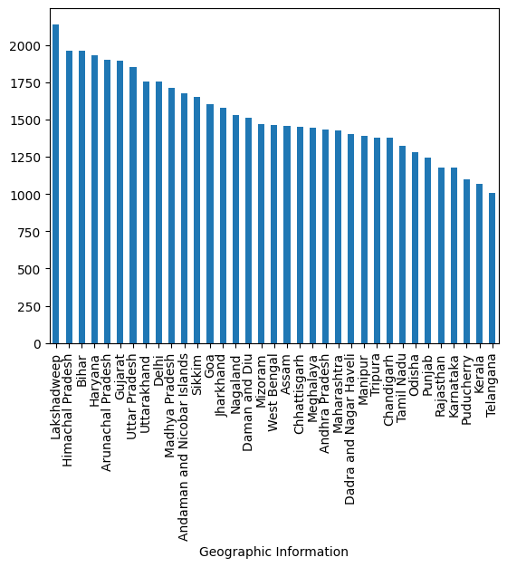

```python
category_plot("Geographic Information")
geo_distribution=df['Geographic Information'].value_counts().sort_index()
print('Geographic distribtuion of customers:')
for geo, count in geo_distribution.items():
    print(f'Geographic information: {geo}, number of customers: {count}')
```

# Output

Demographic Distribution of Customers :

Gender Distribution

1. Gender: Female, numbers of customers : 26004
2. Gender: Male, numbers of customers : 27499

Education level Distribution

The education level distribution among customers showcases a diverse representation of educational backgrounds within the dataset. Notably, there is a substantial presence of customers with associate degrees, totaling 12,213 individuals, and those with doctorates, amounting to 12,103. Additionally, significant numbers of customers hold high school diplomas (10,607), bachelor's degrees (9,214), and master's degrees (9,366).

Geographic distribution

The geographic distribution of customers across various regions presents a diverse representation within the dataset. Notably, there are notable concentrations of customers in specific geographic areas, with Lakshadweep having the highest number of customers at 2,140, followed closely by Himachal Pradesh with 1,963 customers. Additionally, significant numbers of customers are observed in states such as Bihar (1,962), Haryana (1,931), and Uttar Pradesh (1,855). This distribution underscores the varied geographical presence of customers, highlighting potential regional preferences or market opportunities that businesses can leverage for targeted marketing strategies and localized service offerings.

# Conclusion

```python
The demographic distribution analysis of customers presents a comprehensive overview of key characteristics and the insights gleaned reveal a diverse customer base with notable concentrations observed across different demographic segments.
Understanding these demographics is crucial for tailoring marketing strategies, refining product offerings, and enhancing customer engagement.
By recognizing the nuanced preferences and needs within each demographic category, businesses can optimize their approach to effectively reach and serve their diverse customer base, ultimately driving growth and success in the market.
```